# Impact of homelessness on surgical outcomes

# Background

The following observational analysis has been designed to determine the impact of homelessness on surgical outcomes. To assess this impact, if any, we fit several linear models containing their housing status and other potentially confounding variables to determine whether there is an impact and quantify it.

The St Vincent’s Hospital Sydney Coding Office (SVHSCO) provided the data sets relating to these outcomes.

# Methods

Binary logistic regression and linear logistic regression were used to analyse associations between our complication factors as independent variables to each endpoint. Using the outputs from these models, we determine which variables have a significant effect on each outcome. We then remove the non-significant variables from the models to arrive at final models from which we can determine effect sizes for each complication factor.

## Enpoints

The primary efficacy endpoint is:

- Surgical complication as `complication`: logical variable indicating whether the patient had a complication associated with their operation.

and the secondary endpoints include:

- Patient Mortality as `mortality`: a logical variable indicating whether the patient died during their hospital admission.
- Length of Stay as`los` a measurement of in days of how long each patient stayed in hospital.
- ICU Admission as `icu_admission`: a logical variable indicating whether the patient was admitted to ICU.
- ICU Hours as `icu_hrs`: a measurement in hours of how long the patient spent in ICU.
- Discharge against medical advice as `daor`: a logical variable indicating whether patients discharged themselves at their own risk.

## Complication factors

The variable of interest was:

- Housing Status as `status`: the patient’s housing status undergoing surgery.

Other potentially confounding variables considered as part of the analysis were:

- Patient Age as `age`: a measurement of the patient’s age in decades at the time of admission.
- Patient Sex as `sex`: sex of the patient.
- Drug and Alcohol Disorder as `da_disorder`: whether the patient had a drug and alcohol disorder associated with their admission.
- Mental Illness as `mental_illness`: whether the patient had a drug and a mental illness associated with their admission.

The datasets were exported by SVHSCO to a set of google sheets which was then ingested by this analysis document.

# Environment set-up

First we set up our environment by loading the following packages.

```r
# load libraries
library(googlesheets4)
library(googledrive)
library(tidyverse)
library(reshape2)
library(janitor)
library(skimr)
library(scales)
library(ggplot2)
library(ggpubr)
library(chisq.posthoc.test)
library(jtools)
```

# Data load, clean and feature engineering

The data is contained as a google sheet. The following routine fetches, cleans and generates features from these datasets to create an analysis data frame called `homeless_data`.

The cleaning process involves the following processes:

- All non-surgical patient admissions were filtered out of the data set.
- `NA` values for `assoc_diseases` were encoded as `NONE`
- `NA` values for `icu_hrs` were encoded as 0.

The features we generate are:

- `complication`: a logical variable as defined by the inclusion of `assoc_diseases` beginning with `T8`.
- `icu_admission`: logical variable defined by the `icu_hrs` variable greater than 0.
- `da_disorder`: a logical variable defined by the inclusion of `assoc_diseases` beginning with `F1`, except `F17`.
- `mental_illness`: a logical variable defined by the inclusion of `assoc_diseases` beginning with `F2`, `F3` or `F4`.
- `daor`: as logical variable as defined by a `discharge_status` equal to `Discharge at Own Risk` meaning that the patient discharged themselves against medical advice.

```r
# load data by looping through the sheets
sheets <- vector(mode = "list", length = 2)

for (s in 1:2){

  sheets[[s]] <- drive_get("Homeless Data") %>%
    read_sheet(sheet = s) %>%
    clean_names() %>%
    select(sex, age, assoc_diseases, spec, los, icu_hrs, discharge_status) %>%
    mutate(status = c("domiciled", "homeless")[s])

}

# bind the sheets together and clean
homeless_data <- bind_rows(sheets) %>%
  filter(spec %in% c("OT1", "OT2", "CRS", "NS", "HNO", "PLS", "CTS", "VAS", "SOC", "ENT", "URO", "GIT")) %>%
  mutate_at(vars(c("sex", "spec", "discharge_status", "status")), as.factor) %>%
  replace_na(list(assoc_diseases = "NONE",
                  icu_hrs = 0))

# feature engineering
homeless_data <- homeless_data %>%
  mutate(complication = ifelse(str_detect(assoc_diseases, "T8"), T, F),
         age = age/10, # want to represent age in decades in analysis
         mortality = ifelse(str_detect(as.character(discharge_status), "DEATH"), T, F),
         icu_admission = ifelse(icu_hrs > 0, T, F),
         da_disorder = str_detect(assoc_diseases, paste(paste0("F", c(10:16, 18:19)), collapse = "|")),
         mental_illness = case_when(
           str_detect(assoc_diseases, "F2") ~ T,
           str_detect(assoc_diseases, "F3") ~ T,
           str_detect(assoc_diseases, "F4") ~ T,
           TRUE ~ F
           ),
         daor = ifelse(discharge_status == "Discharge at Own Risk", T, F))

# add in descriptions for spec
homeless_data <- homeless_data %>%
  mutate(spec_desc = case_when(
    spec %in% c('GIT', 'CRS', 'HNO', 'SOC') ~ 'GS',
    spec %in% c('OT1', 'OT2')               ~ 'ORT',
    TRUE                                    ~ as.character(spec)
  ) %>% as.factor())

# skim set by status group
homeless_data %>%
  group_by(status) %>%
  skim()
```

Data summary

| Name | Piped data |
| --- | --- |
| Number of rows | 11229 |
| Number of columns | 15 |
| _______________________ |  |
| Column type frequency: |  |
| character | 1 |
| factor | 4 |
| logical | 6 |
| numeric | 3 |
| ________________________ |  |
| Group variables | status |

**Variable type: character**

| skim_variable | status | n_missing | complete_rate | min | max | empty | n_unique | whitespace |
| --- | --- | --- | --- | --- | --- | --- | --- | --- |
| assoc_diseases | domiciled | 0 | 1 | 4 | 254 | 0 | 8760 | 0 |
| assoc_diseases | homeless | 0 | 1 | 4 | 254 | 0 | 221 | 0 |

**Variable type: factor**

| skim_variable | status | n_missing | complete_rate | ordered | n_unique | top_counts |
| --- | --- | --- | --- | --- | --- | --- |
| sex | domiciled | 0 | 1 | FALSE | 2 | M: 6757, F: 4248 |
| sex | homeless | 0 | 1 | FALSE | 2 | M: 170, F: 54 |
| spec | domiciled | 0 | 1 | FALSE | 12 | OT1: 2075, OT2: 1608, CRS: 1545, GIT: 1386 |
| spec | homeless | 0 | 1 | FALSE | 12 | SOC: 34, CRS: 31, PLS: 30, GIT: 26 |
| discharge_status | domiciled | 0 | 1 | FALSE | 8 | Dis: 8346, Tra: 1437, Typ: 726, Dis: 184 |
| discharge_status | homeless | 0 | 1 | FALSE | 8 | Dis: 125, Tra: 39, Dis: 30, Typ: 21 |
| spec_desc | domiciled | 0 | 1 | FALSE | 8 | GS: 4078, ORT: 3683, PLS: 710, CTS: 681 |
| spec_desc | homeless | 0 | 1 | FALSE | 8 | GS: 94, ORT: 41, PLS: 30, CTS: 17 |

**Variable type: logical**

| skim_variable | status | n_missing | complete_rate | mean | count |
| --- | --- | --- | --- | --- | --- |
| complication | domiciled | 0 | 1 | 0.08 | FAL: 10126, TRU: 879 |
| complication | homeless | 0 | 1 | 0.11 | FAL: 199, TRU: 25 |
| mortality | domiciled | 0 | 1 | 0.01 | FAL: 10896, TRU: 109 |
| mortality | homeless | 0 | 1 | 0.00 | FAL: 223, TRU: 1 |
| icu_admission | domiciled | 0 | 1 | 0.14 | FAL: 9495, TRU: 1510 |
| icu_admission | homeless | 0 | 1 | 0.19 | FAL: 182, TRU: 42 |
| da_disorder | domiciled | 0 | 1 | 0.10 | FAL: 9953, TRU: 1052 |
| da_disorder | homeless | 0 | 1 | 0.54 | TRU: 120, FAL: 104 |
| mental_illness | domiciled | 0 | 1 | 0.02 | FAL: 10743, TRU: 262 |
| mental_illness | homeless | 0 | 1 | 0.10 | FAL: 202, TRU: 22 |
| daor | domiciled | 0 | 1 | 0.02 | FAL: 10821, TRU: 184 |
| daor | homeless | 0 | 1 | 0.13 | FAL: 194, TRU: 30 |

**Variable type: numeric**

| skim_variable | status | n_missing | complete_rate | mean | sd | p0 | p25 | p50 | p75 | p100 | hist |
| --- | --- | --- | --- | --- | --- | --- | --- | --- | --- | --- | --- |
| age | domiciled | 0 | 1 | 5.56 | 2.14 | 1.6 | 3.6 | 5.40 | 7.4 | 10.9 | ▇▇▇▆▂ |
| age | homeless | 0 | 1 | 4.90 | 1.35 | 2.0 | 4.0 | 4.75 | 5.7 | 9.0 | ▃▇▆▂▁ |
| los | domiciled | 0 | 1 | 7.15 | 10.33 | 1.0 | 1.0 | 3.00 | 9.0 | 149.0 | ▇▁▁▁▁ |
| los | homeless | 0 | 1 | 10.27 | 14.73 | 1.0 | 2.0 | 5.00 | 11.0 | 115.0 | ▇▁▁▁▁ |
| icu_hrs | domiciled | 0 | 1 | 12.48 | 61.05 | 0.0 | 0.0 | 0.00 | 0.0 | 1361.0 | ▇▁▁▁▁ |
| icu_hrs | homeless | 0 | 1 | 17.65 | 71.38 | 0.0 | 0.0 | 0.00 | 0.0 | 629.0 | ▇▁▁▁▁ |

# Results

## Initial contingency table analysis

First, we perform a one-sided Fisher’s Exact Test to determine whether an association existed between homelessness and greater surgical complication risk.

```r
comp_table <- homeless_data %>%
  with(table(complication, status)) %>%
  .[order(-as.logical(row.names(.))), ]

comp_table
```

```
##             status
## complication domiciled homeless
##        TRUE        879       25
##        FALSE     10126      199
```

```r
comp_table %>%
  fisher.test(., alternative = 'less')
```

```
##
##  Fisher's Exact Test for Count Data
##
## data:  .
## p-value = 0.05928
## alternative hypothesis: true odds ratio is less than 1
## 95 percent confidence interval:
##  0.000000 1.020057
## sample estimates:
## odds ratio
##  0.6910088
```

## Prevalence of confounders amongst population groups

### Continuous confounders

```r
# display summary statistics of age across both populations
homeless_data %>%
  group_by(status) %>%
  summarise(ave_age = mean(age),
            median_age = median(age),
            sd_age = sd(age),
            q0 = quantile(age, 0),
            q25 = quantile(age, 0.25),
            q75 = quantile(age, 0.75),
            q100 = quantile(age, 1))
```

```
## # A tibble: 2 × 8
##   status    ave_age median_age sd_age    q0   q25   q75  q100
##   <fct>       <dbl>      <dbl>  <dbl> <dbl> <dbl> <dbl> <dbl>
## 1 domiciled    5.56       5.4    2.14   1.6   3.6   7.4  10.9
## 2 homeless     4.90       4.75   1.35   2     4     5.7   9
```

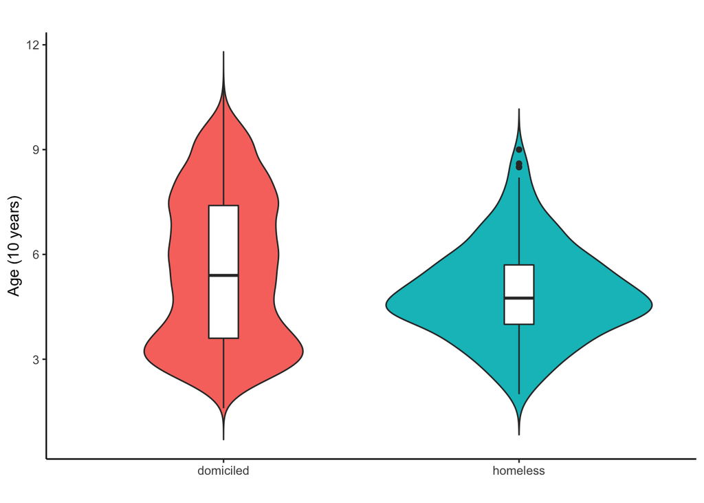

```r
# graph the distributions
p1 <- homeless_data %>%
  ggplot(aes(x = status, y = age, fill = status)) +
    geom_violin(trim = FALSE) +
    geom_boxplot(width = 0.1, fill = "white") +
    labs(title = "", x = "", y = "Age (10 years)") +
    theme_classic() +
    theme(legend.position="none")

p1
```

```r
# conduct test to find whether medians are different
wilcox.test(age ~ status, data = homeless_data)
```

```
##
##  Wilcoxon rank sum test with continuity correction
##
## data:  age by status
## W = 1420582, p-value = 9.04e-05
## alternative hypothesis: true location shift is not equal to 0
```

```r
homeless_data %>%
  group_by(status) %>%
  summarise(age_median = median(age))
```

```
## # A tibble: 2 × 2
##   status    age_median
##   <fct>          <dbl>
## 1 domiciled       5.4
## 2 homeless        4.75
```

### Categorical confounders

```r
# find the contingency tables of confounders amongst both populations
con_tab <- homeless_data %>%
  select(status, sex, da_disorder,  mental_illness) %>%
  lapply(., function(x) table(.$status, x)) %>% .[-1]

con_tab
```

```
## $sex
##            x
##                F    M
##   domiciled 4248 6757
##   homeless    54  170
##
## $da_disorder
##            x
##             FALSE TRUE
##   domiciled  9953 1052
##   homeless    104  120
##
## $mental_illness
##            x
##             FALSE  TRUE
##   domiciled 10743   262
##   homeless    202    22
```

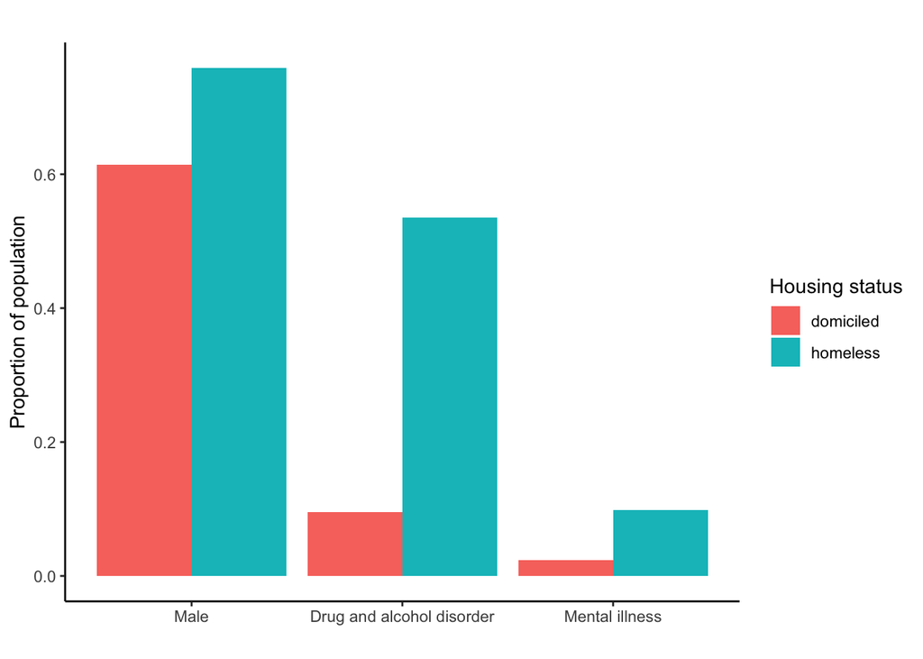

```r
p2 <- homeless_data %>%
  mutate(sex = ifelse(sex == 'M', T, F)) %>%
  group_by(status) %>%
  summarise_at(vars(sex, da_disorder,  mental_illness), function(x) mean(x)) %>%
  melt(variable.name = "confounder", value.name = "proportion") %>%
  ggplot(aes(x = confounder, y = proportion, fill = status)) +
    geom_bar(stat = "identity", position = position_dodge()) +
    labs(title = '',
         fill = 'Housing status') +
    ylab('Proportion of population') +
    xlab('') +
    scale_x_discrete(labels = c("sex" = "Male", "da_disorder" = "Drug and alcohol disorder", "mental_illness" = "Mental illness")) +
    theme_classic()

p2
```

```r
# show these contingency tables as prop tables
con_tab %>% lapply(., function(x) prop.table(x, margin = 1))
```

```
## $sex
##            x
##                     F         M
##   domiciled 0.3860064 0.6139936
##   homeless  0.2410714 0.7589286
##
## $da_disorder
##            x
##                  FALSE       TRUE
##   domiciled 0.90440709 0.09559291
##   homeless  0.46428571 0.53571429
##
## $mental_illness
##            x
##                  FALSE       TRUE
##   domiciled 0.97619264 0.02380736
##   homeless  0.90178571 0.09821429
```

```r
# determine whether the odds of their occurrence is different using fisher test
con_tab %>% lapply(., fisher.test, alternative = 'greater')
```

```
## $sex
##
##  Fisher's Exact Test for Count Data
##
## data:  X[[i]]
## p-value = 3.723e-06
## alternative hypothesis: true odds ratio is greater than 1
## 95 percent confidence interval:
##  1.515382      Inf
## sample estimates:
## odds ratio
##   1.979068
##
##
## $da_disorder
##
##  Fisher's Exact Test for Count Data
##
## data:  X[[i]]
## p-value < 2.2e-16
## alternative hypothesis: true odds ratio is greater than 1
## 95 percent confidence interval:
##  8.620317      Inf
## sample estimates:
## odds ratio
##   10.91182
##
##
## $mental_illness
##
##  Fisher's Exact Test for Count Data
##
## data:  X[[i]]
## p-value = 5.158e-08
## alternative hypothesis: true odds ratio is greater than 1
## 95 percent confidence interval:
##  2.92011     Inf
## sample estimates:
## odds ratio
##   4.464485
```

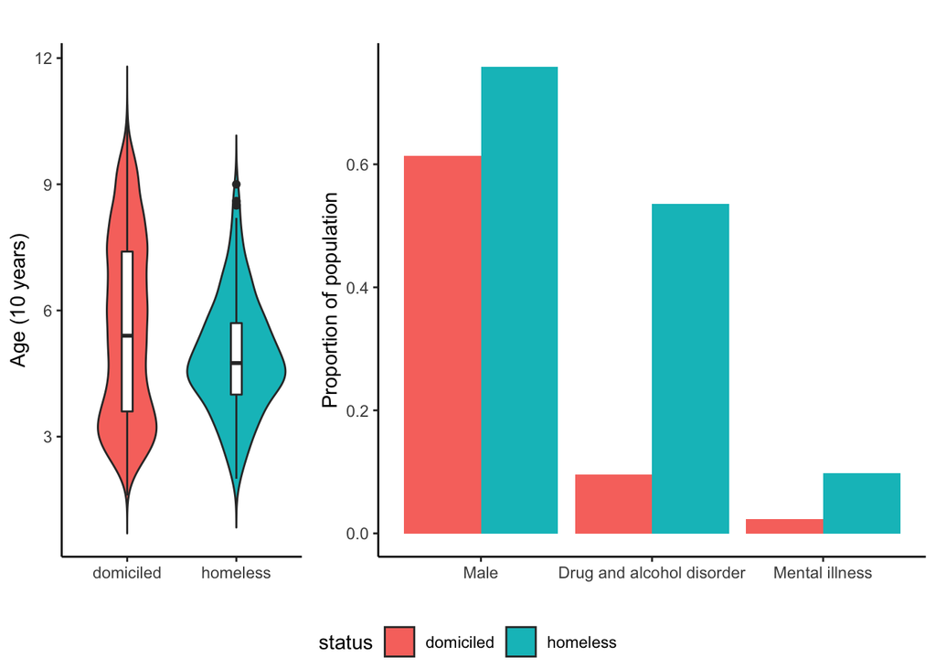

```r
# combine the graphs together
ggarrange(p1, p2,
          widths = c(0.5, 1),
          common.legend = T,
          legend = "bottom")
```

## Linear Regression analysis

Here we fit sets of linear models to our outcomes to determine how the variables we are investigating relate to our outcomes of interest and use the coefficients of the models to determine the potential risk they carry.

### Surgical complication

To determine the effects on complication risk during surgery we fit a logistic regression model to our dataset as so:

```r
comp_glm <- glm(complication ~ status + age + sex + da_disorder + mental_illness,
                family = binomial(),
                data = homeless_data)

comp_glm_summary <- comp_glm %>% summary
comp_glm_summary
```

```
##
## Call:
## glm(formula = complication ~ status + age + sex + da_disorder +
##     mental_illness, family = binomial(), data = homeless_data)
##
## Deviance Residuals:
##     Min       1Q   Median       3Q      Max
## -0.7342  -0.4500  -0.3832  -0.3285   2.6035
##
## Coefficients:
##                    Estimate Std. Error z value Pr(>|z|)
## (Intercept)        -3.70794    0.13038 -28.440  < 2e-16 ***
## statushomeless      0.33132    0.22264   1.488   0.1367
## age                 0.17653    0.01699  10.391  < 2e-16 ***
## sexM                0.30377    0.07510   4.045 5.23e-05 ***
## da_disorderTRUE     0.24161    0.11103   2.176   0.0296 *
## mental_illnessTRUE  0.40058    0.18743   2.137   0.0326 *
## ---
## Signif. codes:  0 '***' 0.001 '**' 0.01 '*' 0.05 '.' 0.1 ' ' 1
##
## (Dispersion parameter for binomial family taken to be 1)
##
##     Null deviance: 6288.3  on 11228  degrees of freedom
## Residual deviance: 6162.5  on 11223  degrees of freedom
## AIC: 6174.5
##
## Number of Fisher Scoring iterations: 5
```

We observe that the variable `status` (P = 0.1367169) didn’t contribute to the model. As such we eliminate the term from the modelling to reach our final model.

```r
comp_glm_final <- glm(complication ~ age + sex + da_disorder + mental_illness,
                      family = binomial(),
                      data = homeless_data)

# get interesting stuff into a df
comp_glm_final %>%
  summ(confint = TRUE, digits = 3)
```

```
## MODEL INFO:
## Observations: 11229
## Dependent Variable: complication
## Type: Generalized linear model
##   Family: binomial
##   Link function: logit
##
## MODEL FIT:
## χ²(4) = 123.703, p = 0.000
## Pseudo-R² (Cragg-Uhler) = 0.026
## Pseudo-R² (McFadden) = 0.020
## AIC = 6174.605, BIC = 6211.236
##
## Standard errors: MLE
## ---------------------------------------------------------------------
##                              Est.     2.5%    97.5%    z val.       p
## ------------------------ -------- -------- -------- --------- -------
## (Intercept)                -3.699   -3.954   -3.444   -28.444   0.000
## age                         0.175    0.142    0.209    10.354   0.000
## sexM                        0.306    0.159    0.453     4.074   0.000
## da_disorderTRUE             0.273    0.060    0.486     2.516   0.012
## mental_illnessTRUE          0.413    0.046    0.780     2.208   0.027
## ---------------------------------------------------------------------
```

```r
# transform the coefficients into risk factors
comp_glm_final %>%
  with(cbind(exp(coefficients(.)), exp(confint(.))))
```

```
##                                    2.5 %    97.5 %
## (Intercept)        0.02474285 0.01912099 0.0318383
## age                1.19180970 1.15298209 1.2321996
## sexM               1.35772818 1.17295917 1.5744210
## da_disorderTRUE    1.31379928 1.05754492 1.6185530
## mental_illnessTRUE 1.51171994 1.03108957 2.1520691
```

### Mortality

To determine the effects on mortality risk during surgery we fit a logistic regression model to our dataset as so:

```r
mort_glm <- glm(mortality ~ status + age + sex + da_disorder + mental_illness,
                family = binomial(),
                data = homeless_data)

mort_glm_summary <- mort_glm %>% summary
mort_glm_summary
```

```
##
## Call:
## glm(formula = mortality ~ status + age + sex + da_disorder +
##     mental_illness, family = binomial(), data = homeless_data)
##
## Deviance Residuals:
##     Min       1Q   Median       3Q      Max
## -0.3035  -0.1643  -0.1230  -0.0956   3.4737
##
## Coefficients:
##                    Estimate Std. Error z value Pr(>|z|)
## (Intercept)        -6.80818    0.40294 -16.896  < 2e-16 ***
## statushomeless     -0.50130    1.01977  -0.492   0.6230
## age                 0.31089    0.04895   6.351 2.13e-10 ***
## sexM                0.45827    0.20810   2.202   0.0277 *
## da_disorderTRUE    -0.01989    0.35744  -0.056   0.9556
## mental_illnessTRUE -1.04566    1.00969  -1.036   0.3004
## ---
## Signif. codes:  0 '***' 0.001 '**' 0.01 '*' 0.05 '.' 0.1 ' ' 1
##
## (Dispersion parameter for binomial family taken to be 1)
##
##     Null deviance: 1236.6  on 11228  degrees of freedom
## Residual deviance: 1189.5  on 11223  degrees of freedom
## AIC: 1201.5
##
## Number of Fisher Scoring iterations: 8
```

We observe that the variables `status` (P = 0.6230142), `da_disorder` (P = 0.9556236) and `mental_illness` (P = 0.300376) don’t contribute to the model. As such we eliminate these terms from the modelling to reach our final model.

```r
mort_glm_final <- glm(mortality ~ age + sex,
                      family = binomial(),
                      data = homeless_data)

# get interesting stuff into a df
mort_glm_final %>%
  summ(confint = TRUE, digits = 3)
```

```
## MODEL INFO:
## Observations: 11229
## Dependent Variable: mortality
## Type: Generalized linear model
##   Family: binomial
##   Link function: logit
##
## MODEL FIT:
## χ²(2) = 45.183, p = 0.000
## Pseudo-R² (Cragg-Uhler) = 0.039
## Pseudo-R² (McFadden) = 0.037
## AIC = 1197.406, BIC = 1219.385
##
## Standard errors: MLE
## --------------------------------------------------------------
##                       Est.     2.5%    97.5%    z val.       p
## ----------------- -------- -------- -------- --------- -------
## (Intercept)         -6.845   -7.627   -6.062   -17.147   0.000
## age                  0.313    0.218    0.409     6.423   0.000
## sexM                 0.454    0.047    0.861     2.187   0.029
## --------------------------------------------------------------
```

### Length of Stay

To determine the effects on a patient’s length of stay, we fit linear models to our dataset. Firstly, we need to make a log transform to our outcome variable to fit the model correctly.

```r
# new log transformed outcome variable
homeless_data <- homeless_data %>%
  mutate(ln_los = log(los))

los_lm <- lm(ln_los ~ status + age + sex + da_disorder + mental_illness,
             data = homeless_data)

los_lm_summary <- los_lm %>% summary
los_lm_summary
```

```
##
## Call:
## lm(formula = ln_los ~ status + age + sex + da_disorder + mental_illness,
##     data = homeless_data)
##
## Residuals:
##     Min      1Q  Median      3Q     Max
## -2.5494 -0.7325 -0.0394  0.6418  3.7378
##
## Coefficients:
##                     Estimate Std. Error t value Pr(>|t|)
## (Intercept)        -0.006356   0.030235  -0.210  0.83349
## statushomeless      0.216642   0.066446   3.260  0.00112 **
## age                 0.227462   0.004343  52.374  < 2e-16 ***
## sexM                0.033744   0.019050   1.771  0.07654 .
## da_disorderTRUE     0.387301   0.030687  12.621  < 2e-16 ***
## mental_illnessTRUE  0.940767   0.058380  16.114  < 2e-16 ***
## ---
## Signif. codes:  0 '***' 0.001 '**' 0.01 '*' 0.05 '.' 0.1 ' ' 1
##
## Residual standard error: 0.9629 on 11223 degrees of freedom
## Multiple R-squared:  0.2237, Adjusted R-squared:  0.2234
## F-statistic: 646.9 on 5 and 11223 DF,  p-value: < 2.2e-16
```

We observe that the variable `sex` (P = 0.0765371) didn’t contribute to the model. As such we eliminate the terms from the modelling to reach our final model.

```r
los_lm_final <- lm(ln_los ~ status + age + da_disorder + mental_illness,
                   data = homeless_data)

# get interesting stuff into a df
los_lm_final %>%
  summ(confint = TRUE, digits = 3)
```

```
## MODEL INFO:
## Observations: 11229
## Dependent Variable: ln_los
## Type: OLS linear regression
##
## MODEL FIT:
## F(4,11224) = 807.730, p = 0.000
## R² = 0.224
## Adj. R² = 0.223
##
## Standard errors: OLS
## ------------------------------------------------------------------
##                             Est.     2.5%   97.5%   t val.       p
## ------------------------ ------- -------- ------- -------- -------
## (Intercept)                0.021   -0.029   0.072    0.828   0.408
## statushomeless             0.219    0.089   0.349    3.299   0.001
## age                        0.226    0.218   0.235   52.851   0.000
## da_disorderTRUE            0.391    0.331   0.451   12.765   0.000
## mental_illnessTRUE         0.939    0.825   1.054   16.087   0.000
## ------------------------------------------------------------------
```

### ICU Admission

To determine the effects on ICU admission risk during surgery, we fit a logistic regression model to our dataset as so:

```r
icu_glm <- glm(icu_admission ~ status + age + sex + da_disorder + mental_illness,
               family = binomial(),
               data = homeless_data)

icu_glm_summary <- icu_glm %>% summary
icu_glm_summary
```

```
##
## Call:
## glm(formula = icu_admission ~ status + age + sex + da_disorder +
##     mental_illness, family = binomial(), data = homeless_data)
##
## Deviance Residuals:
##     Min       1Q   Median       3Q      Max
## -1.6137  -0.5834  -0.4434  -0.3304   2.7170
##
## Coefficients:
##                    Estimate Std. Error z value Pr(>|z|)
## (Intercept)        -4.24741    0.11629 -36.523  < 2e-16 ***
## statushomeless      0.12309    0.18472   0.666    0.505
## age                 0.29075    0.01434  20.271  < 2e-16 ***
## sexM                0.84718    0.06456  13.122  < 2e-16 ***
## da_disorderTRUE     0.62217    0.08395   7.411 1.25e-13 ***
## mental_illnessTRUE  1.20401    0.13504   8.916  < 2e-16 ***
## ---
## Signif. codes:  0 '***' 0.001 '**' 0.01 '*' 0.05 '.' 0.1 ' ' 1
##
## (Dispersion parameter for binomial family taken to be 1)
##
##     Null deviance: 9021.5  on 11228  degrees of freedom
## Residual deviance: 8359.1  on 11223  degrees of freedom
## AIC: 8371.1
##
## Number of Fisher Scoring iterations: 5
```

```r
icu_glm_final <- glm(icu_admission ~ age + sex + da_disorder + mental_illness,
                     family = binomial(),
                     data = homeless_data)

# get interesting stuff into a df
icu_glm_final %>%
  summ(confint = TRUE, digits = 3)
```

```
## MODEL INFO:
## Observations: 11229
## Dependent Variable: icu_admission
## Type: Generalized linear model
##   Family: binomial
##   Link function: logit
##
## MODEL FIT:
## χ²(4) = 662.005, p = 0.000
## Pseudo-R² (Cragg-Uhler) = 0.104
## Pseudo-R² (McFadden) = 0.073
## AIC = 8369.537, BIC = 8406.168
##
## Standard errors: MLE
## ---------------------------------------------------------------------
##                              Est.     2.5%    97.5%    z val.       p
## ------------------------ -------- -------- -------- --------- -------
## (Intercept)                -4.244   -4.471   -4.016   -36.547   0.000
## age                         0.290    0.262    0.318    20.271   0.000
## sexM                        0.848    0.721    0.974    13.133   0.000
## da_disorderTRUE             0.633    0.472    0.794     7.692   0.000
## mental_illnessTRUE          1.208    0.944    1.473     8.958   0.000
## ---------------------------------------------------------------------
```

### ICU Hours

To determine the effects on a patient’s length of stay in ICU, we fit linear models to our data set. Firstly, we need to make a log transform to our outcome variable to fit the model properly.

```r
homeless_data <- homeless_data %>%
  mutate(icu_hrs_trans = ifelse(icu_hrs == 0, NA, log(icu_hrs)))

icu_lm <- lm(icu_hrs_trans ~ status + age + sex + da_disorder + mental_illness,
             data = homeless_data)

icu_lm_summary <- icu_lm %>% summary
icu_lm_summary
```

```
##
## Call:
## lm(formula = icu_hrs_trans ~ status + age + sex + da_disorder +
##     mental_illness, data = homeless_data)
##
## Residuals:
##     Min      1Q  Median      3Q     Max
## -3.9556 -0.7508 -0.0774  0.6792  3.3433
##
## Coefficients:
##                    Estimate Std. Error t value Pr(>|t|)
## (Intercept)         3.89408    0.12284  31.701  < 2e-16 ***
## statushomeless     -0.12179    0.17114  -0.712 0.476798
## age                -0.02787    0.01587  -1.756 0.079249 .
## sexM                0.11444    0.06220   1.840 0.065987 .
## da_disorderTRUE     0.27028    0.07837   3.449 0.000578 ***
## mental_illnessTRUE  0.42143    0.11262   3.742 0.000189 ***
## ---
## Signif. codes:  0 '***' 0.001 '**' 0.01 '*' 0.05 '.' 0.1 ' ' 1
##
## Residual standard error: 1.079 on 1546 degrees of freedom
##   (9677 observations deleted due to missingness)
## Multiple R-squared:  0.02729,    Adjusted R-squared:  0.02414
## F-statistic: 8.674 on 5 and 1546 DF,  p-value: 4.03e-08
```

We observe that the variables `status` (P = 0.4767985) `age` (P = 0.0792487) and `sex` (P = 0.065987) didn’t contribute to the model. As such we eliminate the terms from the modelling to reach our final model.

```r
icu_lm_final <- lm(icu_hrs_trans ~ da_disorder + mental_illness,
                   data = homeless_data)

# get interesting stuff into a df
icu_lm_final %>%
  summ(confint = TRUE, digits = 3)
```

```
## MODEL INFO:
## Observations: 1552 (9677 missing obs. deleted)
## Dependent Variable: icu_hrs_trans
## Type: OLS linear regression
##
## MODEL FIT:
## F(2,1549) = 17.861, p = 0.000
## R² = 0.023
## Adj. R² = 0.021
##
## Standard errors: OLS
## ------------------------------------------------------------------
##                             Est.    2.5%   97.5%    t val.       p
## ------------------------ ------- ------- ------- --------- -------
## (Intercept)                3.789   3.729   3.849   124.410   0.000
## da_disorderTRUE            0.307   0.159   0.455     4.076   0.000
## mental_illnessTRUE         0.422   0.202   0.642     3.756   0.000
## ------------------------------------------------------------------
```

```r
# transform the coefficients into risk factors
icu_lm_final %>%
  with(cbind(exp(coefficients(.)), exp(confint(.))))
```

```
##                                  2.5 %    97.5 %
## (Intercept)        44.204241 41.640971 46.925297
## da_disorderTRUE     1.359421  1.172694  1.575880
## mental_illnessTRUE  1.524559  1.223239  1.900104
```

### Discharge against medical advice

To determine the effects on patients risk to discharge themselves at their risk post-surgery, we fit a logistic regression model to our data set as so:

```r
daor_glm <- glm(daor ~ status + age + sex + da_disorder + mental_illness,
                family = binomial(),
                data = homeless_data)

daor_glm_summary <- daor_glm %>% summary
daor_glm_summary
```

```
##
## Call:
## glm(formula = daor ~ status + age + sex + da_disorder + mental_illness,
##     family = binomial(), data = homeless_data)
##
## Deviance Residuals:
##     Min       1Q   Median       3Q      Max
## -0.8524  -0.1988  -0.1608  -0.1311   3.2300
##
## Coefficients:
##                    Estimate Std. Error z value Pr(>|z|)
## (Intercept)        -3.82954    0.24832 -15.422  < 2e-16 ***
## statushomeless      1.45379    0.22720   6.399 1.57e-10 ***
## age                -0.16447    0.03851  -4.271 1.95e-05 ***
## sexM                0.50786    0.16707   3.040  0.00237 **
## da_disorderTRUE     1.33654    0.15727   8.499  < 2e-16 ***
## mental_illnessTRUE  0.18301    0.33175   0.552  0.58119
## ---
## Signif. codes:  0 '***' 0.001 '**' 0.01 '*' 0.05 '.' 0.1 ' ' 1
##
## (Dispersion parameter for binomial family taken to be 1)
##
##     Null deviance: 2118.9  on 11228  degrees of freedom
## Residual deviance: 1939.3  on 11223  degrees of freedom
## AIC: 1951.3
##
## Number of Fisher Scoring iterations: 7
```

We observe that the variable `mental_illness` (P = 0.5811863) didn’t contribute to the model. As such we eliminate the term from the modelling to reach our final model.

```r
daor_glm_final <- glm(daor ~ status + age + sex + da_disorder,
                      family = binomial(),
                      data = homeless_data)

# get interesting stuff into a df
daor_glm_final %>%
  summ(confint = TRUE, digits = 3)
```

```
## MODEL INFO:
## Observations: 11229
## Dependent Variable: daor
## Type: Generalized linear model
##   Family: binomial
##   Link function: logit
##
## MODEL FIT:
## χ²(4) = 179.321, p = 0.000
## Pseudo-R² (Cragg-Uhler) = 0.092
## Pseudo-R² (McFadden) = 0.085
## AIC = 1949.574, BIC = 1986.205
##
## Standard errors: MLE
## ------------------------------------------------------------------
##                           Est.     2.5%    97.5%    z val.       p
## --------------------- -------- -------- -------- --------- -------
## (Intercept)             -3.825   -4.312   -3.339   -15.412   0.000
## statushomeless           1.461    1.017    1.906     6.444   0.000
## age                     -0.164   -0.240   -0.089    -4.264   0.000
## sexM                     0.505    0.178    0.832     3.025   0.002
## da_disorderTRUE          1.348    1.043    1.653     8.664   0.000
## ------------------------------------------------------------------
```

## get all the models together, derive their risk factors and plot them together

```r
# derive the risk factors from the model coefficients
risks_from_coefs <- function(model, risk_factors = F){

  # get the coefficients into a df
  model_coefs <- model %>%
    with(cbind(coefficients(.), confint(.))) %>% as.data.frame() %>%
    mutate_if(is.numeric, list(exp)) %>%
    mutate(variable = rownames(.)) %>%
    rename("effect_size" = "V1") %>%
    filter(variable != "(Intercept)")

  # # do you want to return the coefficients as risk factors?
  # if(risk_factors == T){
  #
  #   model_coefs <- model_coefs %>%
  #     mutate_if(is.numeric, list(exp))
  #
  # }

  return(model_coefs)

}

lapply(list(comp_glm_final, mort_glm_final, los_lm_final, icu_glm_final, daor_glm_final), risks_from_coefs, risk_factors = T)
```

```
## [[1]]
##                    effect_size    2.5 %   97.5 %           variable
## age                   1.191810 1.152982 1.232200                age
## sexM                  1.357728 1.172959 1.574421               sexM
## da_disorderTRUE       1.313799 1.057545 1.618553    da_disorderTRUE
## mental_illnessTRUE    1.511720 1.031090 2.152069 mental_illnessTRUE
##
## [[2]]
##      effect_size    2.5 %   97.5 % variable
## age     1.367607 1.244747 1.507250      age
## sexM    1.574760 1.055003 2.386901     sexM
##
## [[3]]
##                    effect_size    2.5 %   97.5 %           variable
## statushomeless        1.245084 1.093053 1.418261     statushomeless
## age                   1.253750 1.243278 1.264309                age
## da_disorderTRUE       1.478319 1.392192 1.569774    da_disorderTRUE
## mental_illnessTRUE    2.557701 2.281144 2.867786 mental_illnessTRUE
##
## [[4]]
##                    effect_size    2.5 %   97.5 %           variable
## age                   1.336860 1.300022 1.375106                age
## sexM                  2.334525 2.058849 2.651810               sexM
## da_disorderTRUE       1.883151 1.600294 2.209737    da_disorderTRUE
## mental_illnessTRUE    3.348283 2.563485 4.352190 mental_illnessTRUE
##
## [[5]]
##                 effect_size     2.5 %    97.5 %        variable
## statushomeless     4.312009 2.7240366 6.6420503  statushomeless
## age                0.848555 0.7860082 0.9142403             age
## sexM               1.657280 1.2041931 2.3206384            sexM
## da_disorderTRUE    3.850971 2.8260930 5.2054996 da_disorderTRUE
```

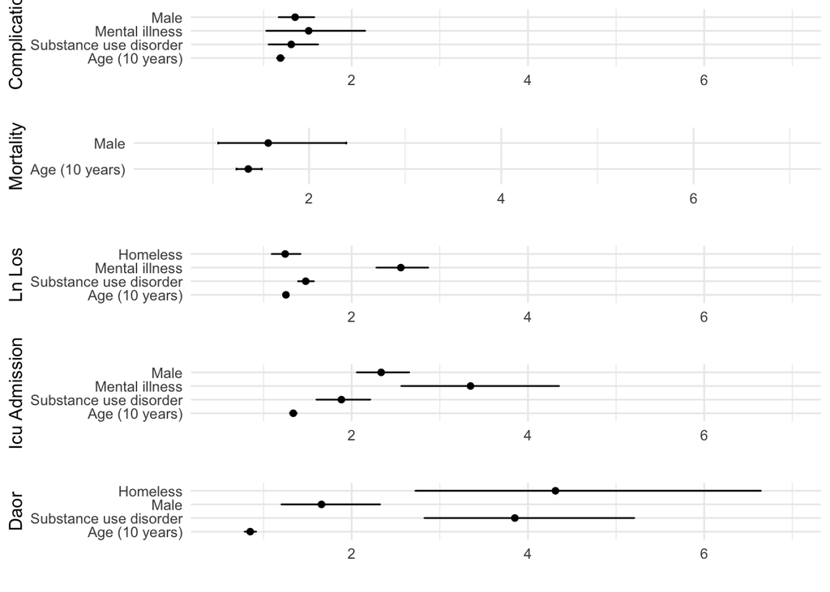

```r
graph_func <- function(model){

  # get the coefficients from the model
  model_coefs <- risks_from_coefs(model)

  # plot them out
  coef_plot <- ggplot(model_coefs, aes(x = variable, y = effect_size)) +
    geom_point() +
    geom_errorbar(aes(ymin = `2.5 %`, ymax = `97.5 %`), width = 0.1) +
    xlab(str_to_title(str_replace_all(model$terms[[2]], "[[:punct:]]", " "))) +
    ylab('') +
    ylim(0.5,7) +
    scale_x_discrete(labels = c("statushomeless" = "Homeless", "age" = "Age (10 years)", "sexM" = "Male", "da_disorderTRUE" = "Substance use disorder", "mental_illnessTRUE" = "Mental illness")) +
    coord_flip() +
    theme_minimal()

  return(coef_plot)

}

coefficient_graphs <- lapply(list(comp_glm_final, mort_glm_final, los_lm_final, icu_glm_final, daor_glm_final), graph_func)

coef_plots <- ggarrange(
  coefficient_graphs[[1]], coefficient_graphs[[2]], coefficient_graphs[[3]], coefficient_graphs[[4]], coefficient_graphs[[5]],
  ncol = 1,
  widths = rep(1, length(coefficient_graphs)),
  common.legend = T,
  legend = "bottom"
  )

coef_plots
```

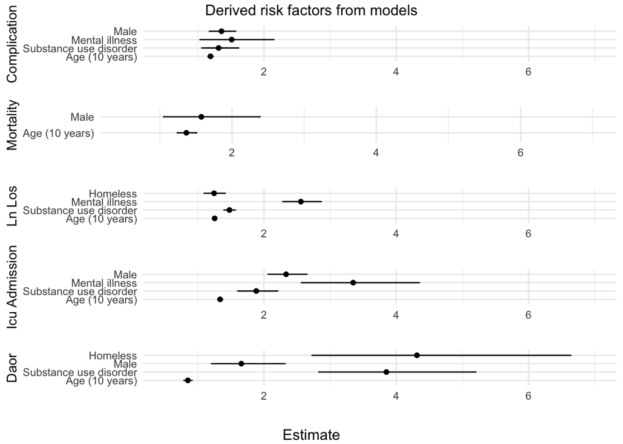

```r
annotate_figure(coef_plots,
                top = text_grob("Derived risk factors from models"),
                bottom = text_grob("Estimate"))
```

## Types of surgery given to the two populations

```r
# generate contingency tables for observed surgeries between groups
surg_tab <- homeless_data %>%
  with(table(status, spec_desc))

surg_tab
```

```
##            spec_desc
## status       CTS  ENT   GS   NS  ORT  PLS  URO  VAS
##   domiciled  681  311 4078  613 3683  710  655  274
##   homeless    17    5   94   12   41   30   14   11
```

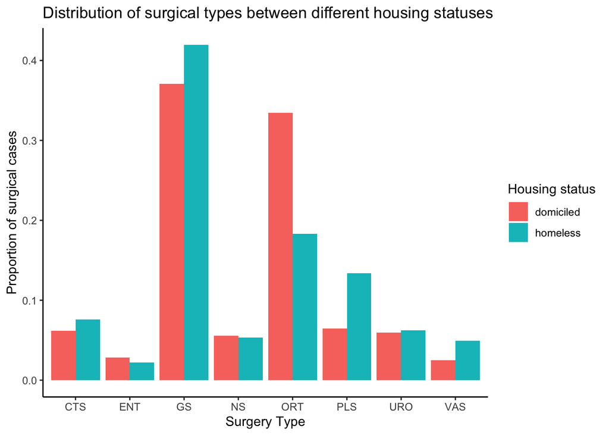

```r
# show this as bar chat of proportions
surg_tab %>% prop.table(., margin = 1) %>%
  as.data.frame() %>%
  ggplot(aes(x = spec_desc, y = Freq, fill = status)) +
    geom_bar(stat = "identity", position = position_dodge()) +
    labs(title = 'Distribution of surgical types between different housing statuses',
         fill = 'Housing status') +
    ylab('Proportion of surgical cases') +
    xlab('Surgery Type') +
    theme_classic()
```

```r
# chi square test to see if the distributions are different
surg_tab %>% chisq.test()
```

```
##
##  Pearson's Chi-squared test
##
## data:  .
## X-squared = 38.782, df = 7, p-value = 2.151e-06
```

```r
# post hoc analysis showing where the differences are
surg_tab %>% chisq.posthoc.test()
```

```
##   Dimension     Value        CTS        ENT        GS         NS       ORT
## 1 domiciled Residuals -0.8598524  0.5320437 -1.505038  0.1376897  4.771946
## 2 domiciled  p values  1.0000000  1.0000000  1.000000  1.0000000  0.000029
## 3  homeless Residuals  0.8598524 -0.5320437  1.505038 -0.1376897 -4.771946
## 4  homeless  p values  1.0000000  1.0000000  1.000000  1.0000000  0.000029
##         PLS        URO       VAS
## 1 -4.145186 -0.1866353 -2.280671
## 2  0.000543  1.0000000  0.361087
## 3  4.145186  0.1866353  2.280671
## 4  0.000543  1.0000000  0.361087
```